# Data analysis pilot study: test framing and bioinspired items

Author

Julius Fenn, Stephanie Bugler

# 1 Notes

# 2 global variables

Define your global variables (can take some time to run):

# 3 create raw data files

```r
# sets the directory of location of this script as the current directory
# setwd(dirname(rstudioapi::getSourceEditorContext()$path))

### load packages
require(pacman)
p_load('tidyverse', 'jsonlite',
       'stargazer',  'DT', 'psych',
       'writexl', 'moments', 'lavaan', 'semPlot', 'mirt', 'MplusAutomation',
       'afex', 'emmeans', 'jtools')


setwd("../01_dataPreperation/outputs")
dat <- read_rds(file = "questionnaire.rds")


### load functions
setwd("../../../functions")
for(i in 1:length(dir())){
  # print(dir()[i])
  source(dir()[i], encoding = "utf-8")
}

rm(i)


### summary function
data_summary <- function(data, varname, groupnames){
  require(plyr)
  summary_func <- function(x, col){
    c(mean = mean(x[[col]], na.rm=TRUE),
      se = sd(x[[col]], na.rm=TRUE) / sqrt(length(x[[col]])))
  }
  data_sum<-ddply(data, groupnames, .fun=summary_func,
                  varname)
  data_sum <- plyr::rename(data_sum, c("mean" = varname))
  return(data_sum)
}
```

# 4 Evaluate questionnaires

## 4.1 Descriptives

To describe sample

```r
psych::describe(dat[, c("sociodemo_age")])
```

```
   vars   n  mean    sd median trimmed   mad min max range skew kurtosis   se
X1    1 594 45.71 13.44     45   45.47 16.31  18  83    65 0.15    -0.86 0.55
```

```r
table(dat$sociodemo_gender)
```

```
female   male
   270    324
```

```r
table(dat$sociodemo_priorExperience)
```

```
             new         not_sure somewhat_similar     very_similar
             560               10               17                7
```

To describe length of study:

```r
psych::describe(dat[, c("total_min_prolific")])
```

```
   vars   n mean  sd median trimmed  mad  min   max range skew kurtosis   se
X1    1 594 5.48 3.5    4.6    4.82 1.72 1.82 28.25 26.43 3.22    13.51 0.14
```

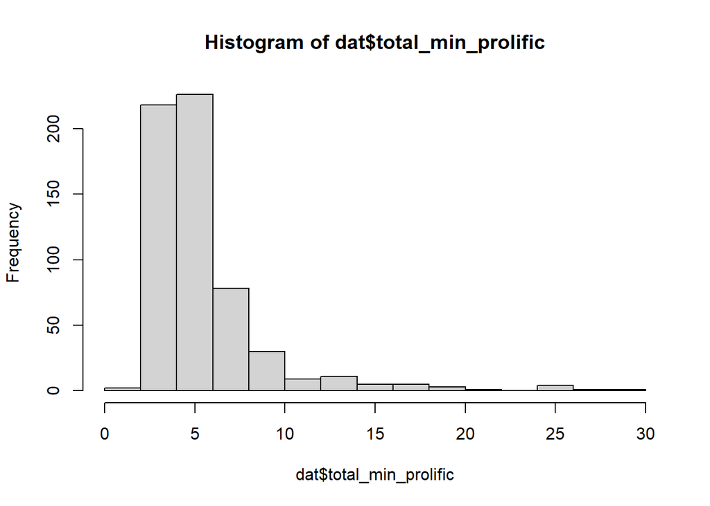

```r
hist(dat$total_min_prolific)
```

To describe conditions:

```r
table(dat$framingCondition, dat$whichItemsFirst)
```

```
              bioinspired sustainable
  bioinspired         198           0
  neutral              96         101
  sustainable           0         199
```

## 4.2 Overall EFA

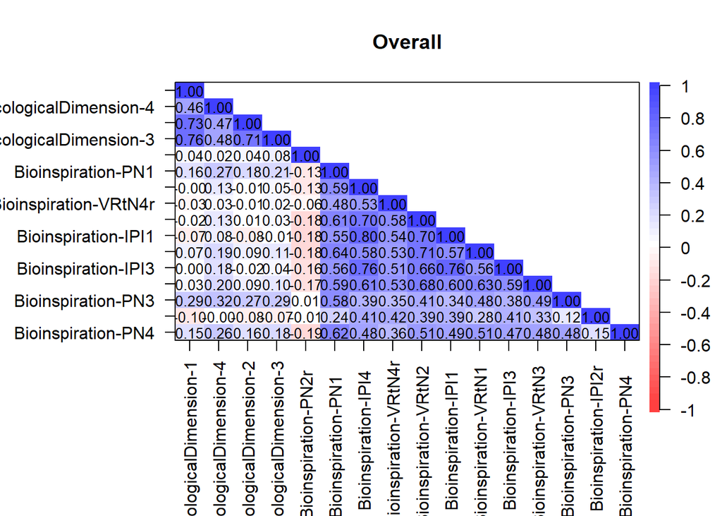

```
#> parallel analysis
```

```r
#### Overall EFA
regExOverall <- "^Bioinspiration|^EcologicalDimension"


psych::cor.plot(r = cor(dat[, str_detect(string = colnames(dat),
                                                   pattern = regExOverall)]
                        , use = "pairwise.complete.obs"),
                upper = FALSE, xlas = 2, main = "Overall")
```

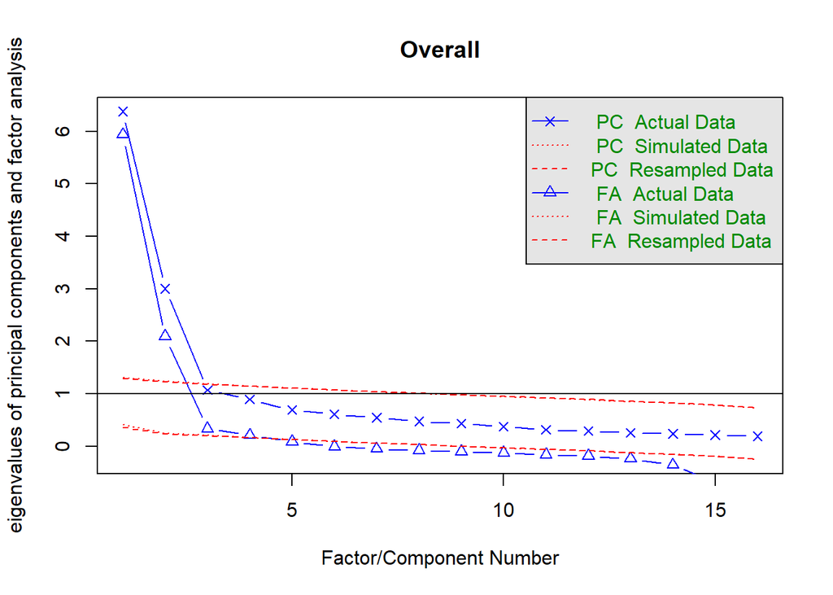

```
Parallel analysis suggests that the number of factors =  4  and the number of components =  2
Overall
Number of components:  2
```

[output not shown]

```r
tmp_parallelAnalysis <- dimensionalityTest(label = "Overall",
                             regEx = regExOverall, dataset = dat)
```

```r
tmp_EFA <- explorativeFactorAnalysis(label = "Overall",
                                 regEx = regExOverall,
                                 dataset = dat, nfac = 2)
tmp_EFA[[1]]
```

```
Factor Analysis using method =  minres
Call: fa(r = tmp_dat, nfactors = nfac, rotate = "promax", cor = "cor")
Standardized loadings (pattern matrix) based upon correlation matrix
                        MR1   MR2    h2   u2 com
EcologicalDimension-1 -0.14  0.87 0.740 0.26 1.0
EcologicalDimension-4  0.10  0.57 0.350 0.65 1.1
EcologicalDimension-2 -0.11  0.84 0.682 0.32 1.0
EcologicalDimension-3 -0.07  0.85 0.710 0.29 1.0
Bioinspiration-PN2r   -0.20  0.07 0.039 0.96 1.2
Bioinspiration-PN1     0.72  0.23 0.621 0.38 1.2
Bioinspiration-IPI4    0.84 -0.04 0.700 0.30 1.0
Bioinspiration-VRtN4r  0.67 -0.06 0.442 0.56 1.0
Bioinspiration-VRtN2   0.86 -0.04 0.723 0.28 1.0
Bioinspiration-IPI1    0.85 -0.13 0.708 0.29 1.0
Bioinspiration-VRtN1   0.75  0.09 0.600 0.40 1.0
Bioinspiration-IPI3    0.82 -0.04 0.656 0.34 1.0
Bioinspiration-VRtN3   0.76  0.07 0.598 0.40 1.0
Bioinspiration-PN3     0.48  0.36 0.412 0.59 1.8
Bioinspiration-IPI2r   0.46 -0.15 0.209 0.79 1.2
Bioinspiration-PN4     0.59  0.21 0.432 0.57 1.2

                       MR1  MR2
SS loadings           5.82 2.80
Proportion Var        0.36 0.18
Cumulative Var        0.36 0.54
Proportion Explained  0.68 0.32
Cumulative Proportion 0.68 1.00

 With factor correlations of
     MR1  MR2
MR1 1.00 0.17
MR2 0.17 1.00

Mean item complexity =  1.1
Test of the hypothesis that 2 factors are sufficient.

df null model =  120  with the objective function =  9.47 with Chi Square =  5560.09
df of  the model are 89  and the objective function was  0.82

The root mean square of the residuals (RMSR) is  0.04
The df corrected root mean square of the residuals is  0.05

The harmonic n.obs is  594 with the empirical chi square  230.42  with prob <  1.7e-14
The total n.obs was  594  with Likelihood Chi Square =  480.1  with prob <  6e-55

Tucker Lewis Index of factoring reliability =  0.903
RMSEA index =  0.086  and the 90 % confidence intervals are  0.079 0.094
BIC =  -88.33
Fit based upon off diagonal values = 0.99
Measures of factor score adequacy
                                                   MR1  MR2
Correlation of (regression) scores with factors   0.97 0.95
Multiple R square of scores with factors          0.94 0.90
Minimum correlation of possible factor scores     0.88 0.79
```

> two factor structure, within bioinspiried dimensions no strong differences in overall answering patterns; 1 items is dysfunctional (negative correlated)

### 4.2.1 for “Bioinspiration Items”

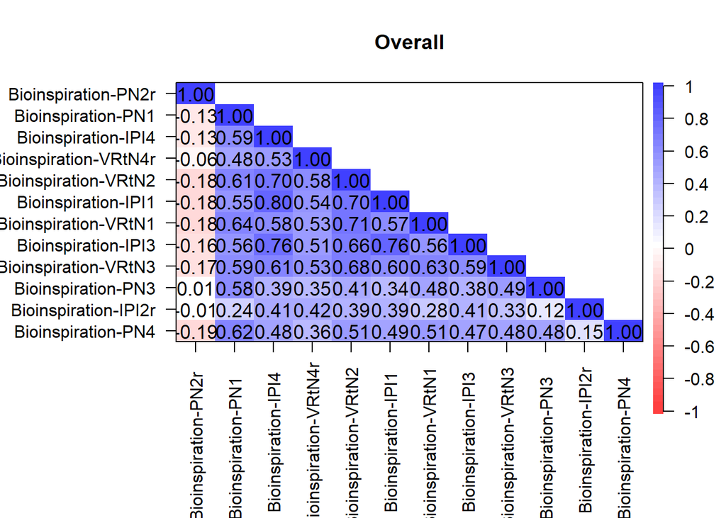

```
#> parallel analysis
```

```r
#### Overall EFA
regExOverall <- "^Bioinspiration"


psych::cor.plot(r = cor(dat[, str_detect(string = colnames(dat),
                                                   pattern = regExOverall)]
                        , use = "pairwise.complete.obs"),
                upper = FALSE, xlas = 2, main = "Overall")
```

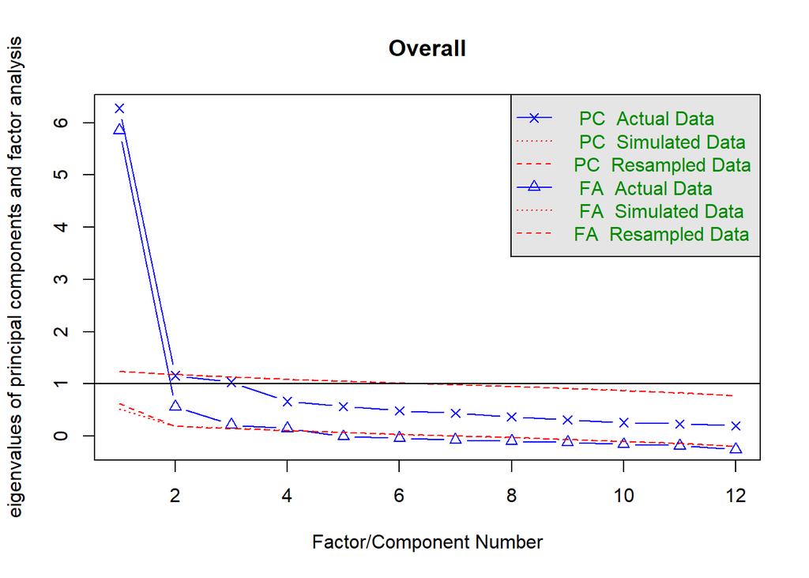

```
Parallel analysis suggests that the number of factors =  4  and the number of components =  1
Overall
Number of components:  1
```

[output not shown]

```r
tmp_parallelAnalysis <- dimensionalityTest(label = "Overall",
                             regEx = regExOverall, dataset = dat)
```

```r
tmp_EFA <- explorativeFactorAnalysis(label = "Overall",
                                 regEx = regExOverall,
                                 dataset = dat, nfac = 2)
tmp_EFA[[1]]
```

```
Factor Analysis using method =  minres
Call: fa(r = tmp_dat, nfactors = nfac, rotate = "promax", cor = "cor")
Standardized loadings (pattern matrix) based upon correlation matrix
                        MR1   MR2    h2   u2 com
Bioinspiration-PN2r   -0.11 -0.09 0.033 0.97 1.9
Bioinspiration-PN1     0.02  0.83 0.713 0.29 1.0
Bioinspiration-IPI4    0.80  0.09 0.753 0.25 1.0
Bioinspiration-VRtN4r  0.52  0.19 0.442 0.56 1.3
Bioinspiration-VRtN2   0.58  0.32 0.714 0.29 1.6
Bioinspiration-IPI1    0.85  0.03 0.758 0.24 1.0
Bioinspiration-VRtN1   0.26  0.58 0.623 0.38 1.4
Bioinspiration-IPI3    0.77  0.09 0.700 0.30 1.0
Bioinspiration-VRtN3   0.37  0.46 0.597 0.40 1.9
Bioinspiration-PN3    -0.20  0.82 0.476 0.52 1.1
Bioinspiration-IPI2r   0.66 -0.21 0.277 0.72 1.2
Bioinspiration-PN4    -0.02  0.72 0.498 0.50 1.0

                       MR1  MR2
SS loadings           3.59 2.99
Proportion Var        0.30 0.25
Cumulative Var        0.30 0.55
Proportion Explained  0.55 0.45
Cumulative Proportion 0.55 1.00

 With factor correlations of
     MR1  MR2
MR1 1.00 0.72
MR2 0.72 1.00

Mean item complexity =  1.3
Test of the hypothesis that 2 factors are sufficient.

df null model =  66  with the objective function =  7.1 with Chi Square =  4173.53
df of  the model are 43  and the objective function was  0.34

The root mean square of the residuals (RMSR) is  0.03
The df corrected root mean square of the residuals is  0.04

The harmonic n.obs is  594 with the empirical chi square  95.74  with prob <  6.9e-06
The total n.obs was  594  with Likelihood Chi Square =  199.61  with prob <  4.9e-22

Tucker Lewis Index of factoring reliability =  0.941
RMSEA index =  0.078  and the 90 % confidence intervals are  0.068 0.09
BIC =  -75.03
Fit based upon off diagonal values = 0.99
Measures of factor score adequacy
                                                   MR1  MR2
Correlation of (regression) scores with factors   0.96 0.94
Multiple R square of scores with factors          0.92 0.89
Minimum correlation of possible factor scores     0.84 0.77
```

## 4.3 Descriptives, correlation plot, EFA, CFA for “Ecological Items”

Applied a self-written function for example to check the reliability and amount of explained variance for the first factor:

```r
regEx <- "^EcologicalDimension"
nameVariable <- "Ecology"


sum(str_detect(string = colnames(dat), pattern = regEx))
```

```
[1] 4
```

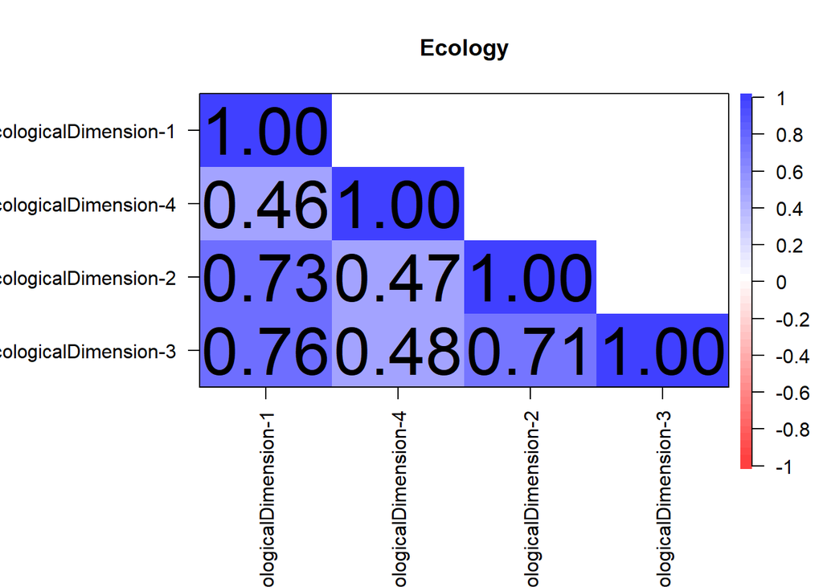

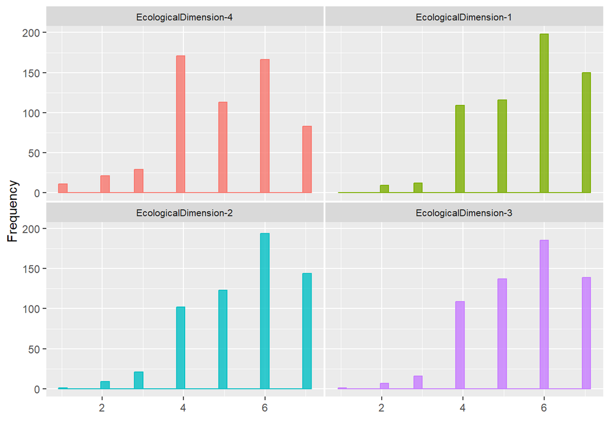

```
descriptive statistics:
                      Mean   SD Median CoeffofVariation Minimum Maximun
EcologicalDimension-1 5.57 1.19      6             0.21       2       7
EcologicalDimension-4 4.99 1.39      5             0.28       1       7
EcologicalDimension-2 5.52 1.23      6             0.22       1       7
EcologicalDimension-3 5.50 1.19      6             0.22       1       7
                      Lower Quantile Upper Quantile Skewness Kurtosis(-3)
EcologicalDimension-1              2              7    -0.60        -0.25
EcologicalDimension-4              1              7    -0.51        -0.02
EcologicalDimension-2              1              7    -0.64        -0.11
EcologicalDimension-3              1              7    -0.53        -0.20
                      KS-Test
EcologicalDimension-1       0
EcologicalDimension-4       0
EcologicalDimension-2       0
EcologicalDimension-3       0


variables under investigation:  EcologicalDimension1 EcologicalDimension4 EcologicalDimension2 EcologicalDimension3

Cronbachs Alpha: 0.86
```

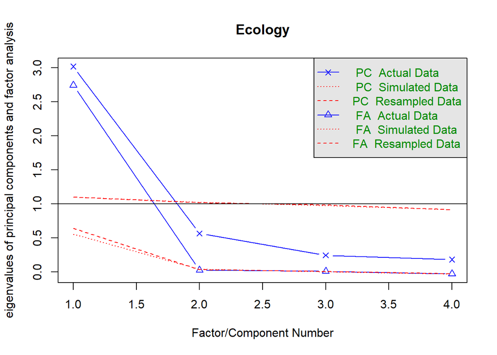

```
Parallel analysis suggests that the number of factors =  1  and the number of components =  1
Ecology
Number of components:  1



EFA factor loadings (1 factor solution):

Loadings:
                     MR1
EcologicalDimension1 0.903
EcologicalDimension4 0.611
EcologicalDimension2 0.870
EcologicalDimension3 0.893

                 MR1
SS loadings    2.743
Proportion Var 0.686
CFA summary and fit statistics:
lavaan 0.6-19 ended normally after 19 iterations

  Estimator                                         ML
  Optimization method                           NLMINB
  Number of model parameters                         8

  Number of observations                           594

Model Test User Model:
                                              Standard      Scaled
  Test Statistic                                 3.186       1.890
  Degrees of freedom                                 2           2
  P-value (Chi-square)                           0.203       0.389
  Scaling correction factor                                  1.686
    Yuan-Bentler correction (Mplus variant)

Model Test Baseline Model:

  Test statistic                              1226.980     561.496
  Degrees of freedom                                 6           6
  P-value                                        0.000       0.000
```

[output cut: 47 more lines]

```
Latent Variables:
                   Estimate  Std.Err  z-value  P(>|z|)   Std.lv  Std.all
  Ecology =~
    EcologclDmnsn1    1.000                               1.048    0.880
    EcologclDmnsn4    0.727    0.054   13.516    0.000    0.762    0.548
    EcologclDmnsn2    0.969    0.044   21.792    0.000    1.016    0.828
    EcologclDmnsn3    0.979    0.040   24.603    0.000    1.027    0.861

Variances:
                   Estimate  Std.Err  z-value  P(>|z|)   Std.lv  Std.all
   .EcologclDmnsn1    0.321    0.046    6.975    0.000    0.321    0.226
   .EcologclDmnsn4    1.355    0.133   10.190    0.000    1.355    0.700
   .EcologclDmnsn2    0.474    0.049    9.671    0.000    0.474    0.315
   .EcologclDmnsn3    0.367    0.058    6.290    0.000    0.367    0.258
    Ecology           1.099    0.087   12.637    0.000    1.000    1.000
```

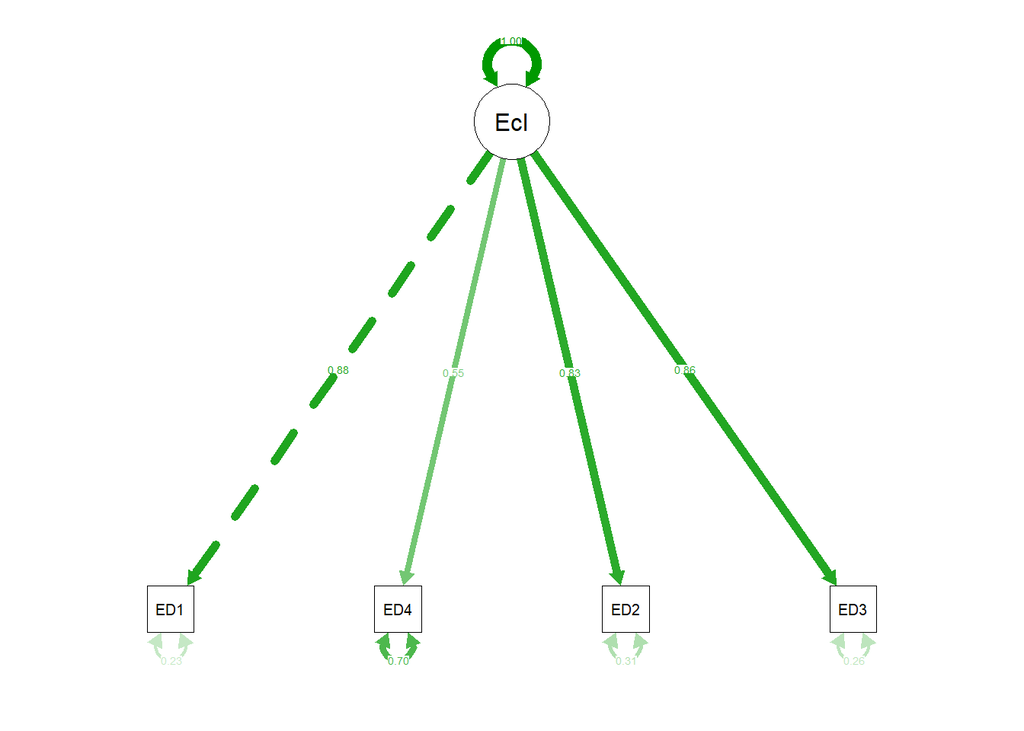

```
CFA first 6 Modification Indices:
                    lhs op                  rhs    mi    epc sepc.lv sepc.all
15 EcologicalDimension2 ~~ EcologicalDimension3 2.938 -0.086  -0.086   -0.205
10 EcologicalDimension1 ~~ EcologicalDimension4 2.938 -0.066  -0.066   -0.100
12 EcologicalDimension1 ~~ EcologicalDimension3 1.455  0.068   0.068    0.197
13 EcologicalDimension4 ~~ EcologicalDimension2 1.455  0.049   0.049    0.061
11 EcologicalDimension1 ~~ EcologicalDimension2 0.387  0.033   0.033    0.083
14 EcologicalDimension4 ~~ EcologicalDimension3 0.387  0.024   0.024    0.034
   sepc.nox
15   -0.205
10   -0.100
12    0.197
13    0.061
11    0.083
14    0.034
```

```r
tmp_dat <- na.omit(dat[,str_detect(string = colnames(dat), pattern = regEx)])


tmp <- CFAstats(dataset = tmp_dat, regularExp = regEx, labelLatent = str_remove(string = nameVariable, pattern = "mean_"),
                showPlots = TRUE,
                computeEFA = TRUE,
                computeCFA = TRUE,
                computeCFAMplus = FALSE)
```

## 4.4 Descriptives, correlation plot, EFA, CFA for “Bioinspiration Items”

### 4.4.1 overall

```r
regEx <- "^Bioinspiration"
nameVariable <- "Bioinspiration"


sum(str_detect(string = colnames(dat), pattern = regEx))
```

```
[1] 12
```

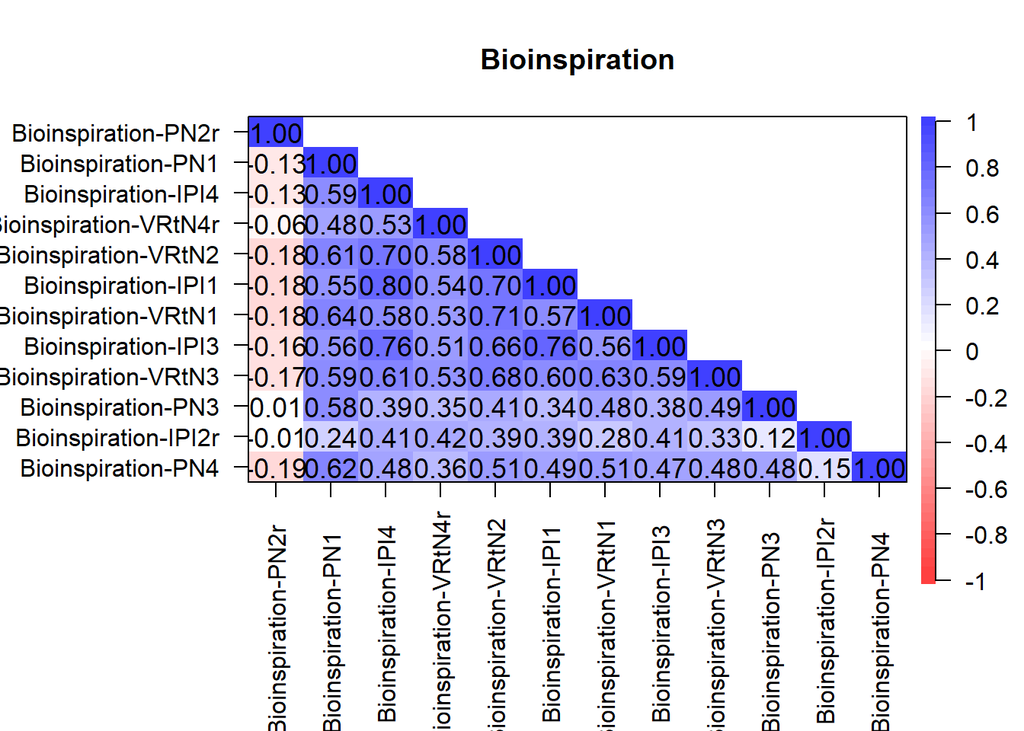

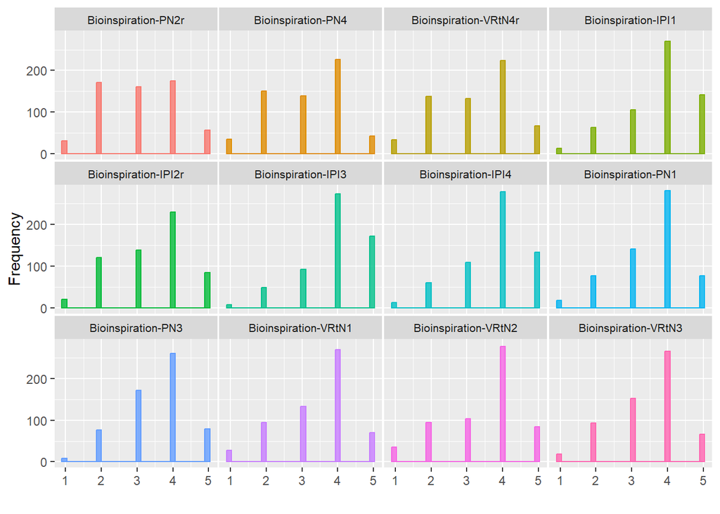

```
descriptive statistics:
                      Mean   SD Median CoeffofVariation Minimum Maximun
Bioinspiration-PN2r   3.09 1.08      3             0.35       1       5
Bioinspiration-PN1    3.54 0.97      4             0.28       1       5
Bioinspiration-IPI4   3.78 0.97      4             0.26       1       5
Bioinspiration-VRtN4r 3.26 1.10      3             0.34       1       5
Bioinspiration-VRtN2  3.47 1.10      4             0.32       1       5
Bioinspiration-IPI1   3.78 1.00      4             0.26       1       5
Bioinspiration-VRtN1  3.44 1.04      4             0.30       1       5
Bioinspiration-IPI3   3.93 0.94      4             0.24       1       5
Bioinspiration-VRtN3  3.45 0.98      4             0.28       1       5
Bioinspiration-PN3    3.55 0.92      4             0.26       1       5
Bioinspiration-IPI2r  3.40 1.06      4             0.31       1       5
Bioinspiration-PN4    3.15 1.07      3             0.34       1       5
                      Lower Quantile Upper Quantile Skewness Kurtosis(-3)
Bioinspiration-PN2r                1              5     0.02        -0.88
Bioinspiration-PN1                 1              5    -0.61        -0.08
Bioinspiration-IPI4                1              5    -0.73         0.11
Bioinspiration-VRtN4r              1              5    -0.27        -0.85
Bioinspiration-VRtN2               1              5    -0.64        -0.40
Bioinspiration-IPI1                1              5    -0.73         0.03
Bioinspiration-VRtN1               1              5    -0.56        -0.36
Bioinspiration-IPI3                1              5    -0.83         0.32
Bioinspiration-VRtN3               1              5    -0.49        -0.34
Bioinspiration-PN3                 1              5    -0.38        -0.32
Bioinspiration-IPI2r               1              5    -0.31        -0.75
Bioinspiration-PN4                 1              5    -0.24        -0.87
                      KS-Test
Bioinspiration-PN2r         0
Bioinspiration-PN1          0
Bioinspiration-IPI4         0
Bioinspiration-VRtN4r       0
Bioinspiration-VRtN2        0
Bioinspiration-IPI1         0
Bioinspiration-VRtN1        0
Bioinspiration-IPI3         0
Bioinspiration-VRtN3        0
Bioinspiration-PN3          0
Bioinspiration-IPI2r        0
Bioinspiration-PN4          0


variables under investigation:  BioinspirationPN2r BioinspirationPN1 BioinspirationIPI4 BioinspirationVRtN4r BioinspirationVRtN2 BioinspirationIPI1 BioinspirationVRtN1 BioinspirationIPI3 BioinspirationVRtN3 BioinspirationPN3 BioinspirationIPI2r BioinspirationPN4
```

```
Some items ( Bioinspiration-PN2r ) were negatively correlated with the first principal component and
probably should be reversed.
To do this, run the function again with the 'check.keys=TRUE' optionCronbachs Alpha: 0.89
```

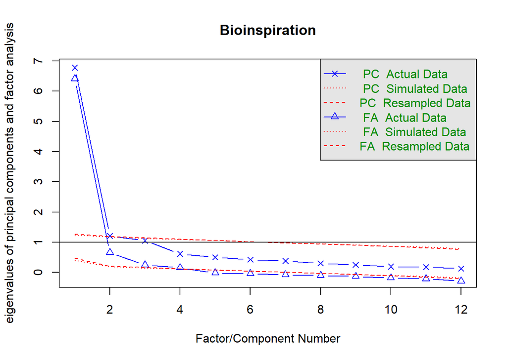

```
Parallel analysis suggests that the number of factors =  4  and the number of components =  2
Bioinspiration
Number of components:  2
```

```
EFA factor loadings (1 factor solution):

Loadings:
                     MR1
BioinspirationPN2r   -0.173
BioinspirationPN1     0.794
BioinspirationIPI4    0.866
BioinspirationVRtN4r  0.690
BioinspirationVRtN2   0.883
BioinspirationIPI1    0.845
BioinspirationVRtN1   0.814
BioinspirationIPI3    0.842
BioinspirationVRtN3   0.816
BioinspirationPN3     0.581
BioinspirationIPI2r   0.461
BioinspirationPN4     0.669

                 MR1
SS loadings    6.412
Proportion Var 0.534
CFA summary and fit statistics:
lavaan 0.6-19 ended normally after 51 iterations

  Estimator                                         ML
  Optimization method                           NLMINB
  Number of model parameters                        24

  Number of observations                           594

Model Test User Model:
                                              Standard      Scaled
  Test Statistic                               524.698     412.126
  Degrees of freedom                                54          54
  P-value (Chi-square)                           0.000       0.000
  Scaling correction factor                                  1.273
    Yuan-Bentler correction (Mplus variant)

Model Test Baseline Model:

  Test statistic                              4214.921    3159.829
```

[output cut: 65 more lines]

```
Variances:
                   Estimate  Std.Err  z-value  P(>|z|)   Std.lv  Std.all
   .BioinsprtnPN2r    1.119    0.053   20.947    0.000    1.119    0.964
   .BioinspirtnPN1    0.431    0.038   11.475    0.000    0.431    0.455
   .BioinsprtnIPI4    0.264    0.026   10.047    0.000    0.264    0.279
   .BinsprtnVRtN4r    0.691    0.063   10.986    0.000    0.691    0.569
   .BionsprtnVRtN2    0.344    0.032   10.661    0.000    0.344    0.286
   .BioinsprtnIPI1    0.290    0.028   10.275    0.000    0.290    0.293
   .BionsprtnVRtN1    0.453    0.039   11.714    0.000    0.453    0.421
   .BioinsprtnIPI3    0.291    0.026   11.342    0.000    0.291    0.327
   .BionsprtnVRtN3    0.404    0.032   12.571    0.000    0.404    0.419
   .BioinspirtnPN3    0.615    0.038   16.398    0.000    0.615    0.723
   .BionsprtnIPI2r    0.912    0.057   16.096    0.000    0.912    0.806
   .BioinspirtnPN4    0.702    0.044   16.009    0.000    0.702    0.618
    Bioinspiration    0.042    0.021    1.934    0.053    1.000    1.000
```

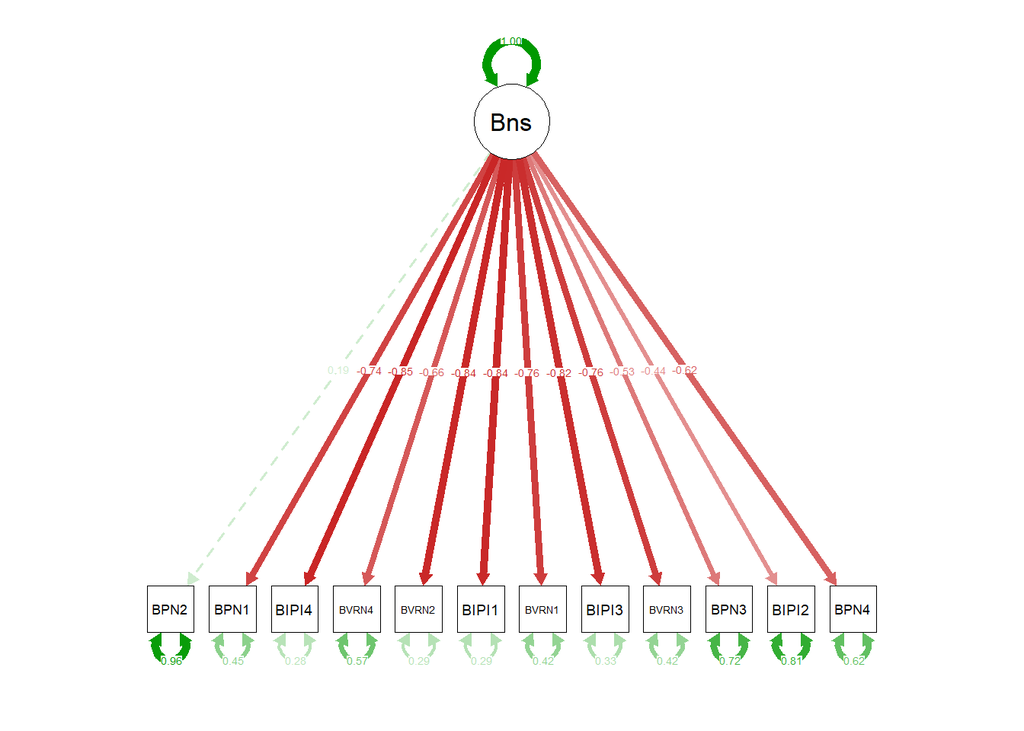

```
CFA first 6 Modification Indices:
                  lhs op                rhs     mi    epc sepc.lv sepc.all
49 BioinspirationIPI4 ~~ BioinspirationIPI1 83.606  0.132   0.132    0.476
44  BioinspirationPN1 ~~  BioinspirationPN3 71.077  0.188   0.188    0.366
46  BioinspirationPN1 ~~  BioinspirationPN4 67.447  0.198   0.198    0.360
72 BioinspirationIPI1 ~~ BioinspirationIPI3 52.170  0.106   0.106    0.363
51 BioinspirationIPI4 ~~ BioinspirationIPI3 43.220  0.093   0.093    0.334
74 BioinspirationIPI1 ~~  BioinspirationPN3 35.797 -0.115  -0.115   -0.273
   sepc.nox
49    0.476
44    0.366
46    0.360
72    0.363
51    0.334
74   -0.273
```

```r
tmp_dat <- na.omit(dat[,str_detect(string = colnames(dat), pattern = regEx)])


tmp <- CFAstats(dataset = tmp_dat, regularExp = regEx, labelLatent = str_remove(string = nameVariable, pattern = "mean_"),
                showPlots = TRUE,
                computeEFA = TRUE,
                computeCFA = TRUE,
                computeCFAMplus = FALSE)
```

### 4.4.2 overall

```r
regEx <- "^Bioinspiration"
nameVariable <- "Bioinspiration"


sum(str_detect(string = colnames(dat), pattern = regEx))
```

```
[1] 12
```

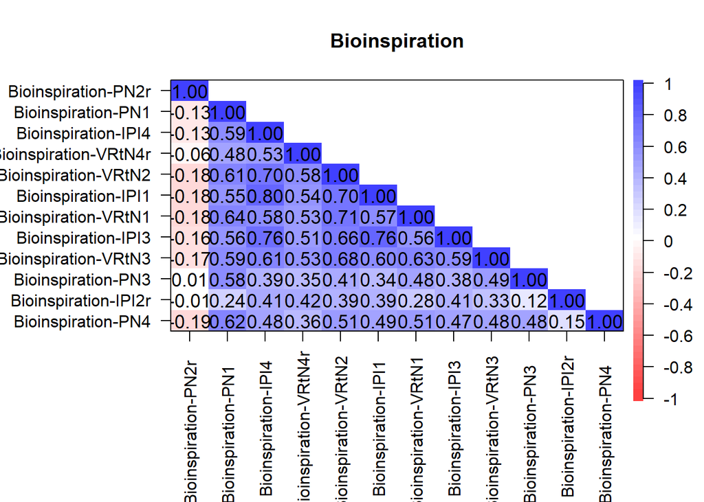

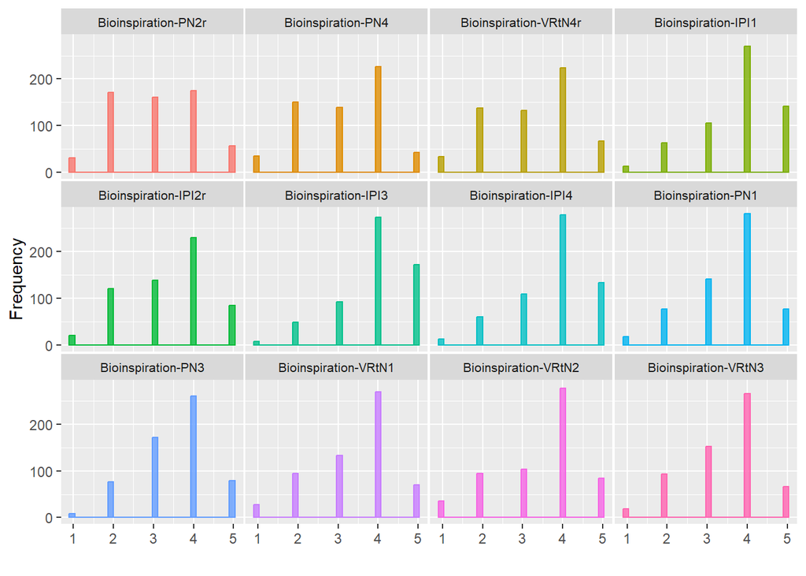

```
descriptive statistics:
                      Mean   SD Median CoeffofVariation Minimum Maximun
Bioinspiration-PN2r   3.09 1.08      3             0.35       1       5
Bioinspiration-PN1    3.54 0.97      4             0.28       1       5
Bioinspiration-IPI4   3.78 0.97      4             0.26       1       5
Bioinspiration-VRtN4r 3.26 1.10      3             0.34       1       5
Bioinspiration-VRtN2  3.47 1.10      4             0.32       1       5
Bioinspiration-IPI1   3.78 1.00      4             0.26       1       5
Bioinspiration-VRtN1  3.44 1.04      4             0.30       1       5
Bioinspiration-IPI3   3.93 0.94      4             0.24       1       5
Bioinspiration-VRtN3  3.45 0.98      4             0.28       1       5
Bioinspiration-PN3    3.55 0.92      4             0.26       1       5
Bioinspiration-IPI2r  3.40 1.06      4             0.31       1       5
Bioinspiration-PN4    3.15 1.07      3             0.34       1       5
                      Lower Quantile Upper Quantile Skewness Kurtosis(-3)
Bioinspiration-PN2r                1              5     0.02        -0.88
Bioinspiration-PN1                 1              5    -0.61        -0.08
Bioinspiration-IPI4                1              5    -0.73         0.11
Bioinspiration-VRtN4r              1              5    -0.27        -0.85
Bioinspiration-VRtN2               1              5    -0.64        -0.40
Bioinspiration-IPI1                1              5    -0.73         0.03
Bioinspiration-VRtN1               1              5    -0.56        -0.36
Bioinspiration-IPI3                1              5    -0.83         0.32
Bioinspiration-VRtN3               1              5    -0.49        -0.34
Bioinspiration-PN3                 1              5    -0.38        -0.32
Bioinspiration-IPI2r               1              5    -0.31        -0.75
Bioinspiration-PN4                 1              5    -0.24        -0.87
                      KS-Test
Bioinspiration-PN2r         0
Bioinspiration-PN1          0
Bioinspiration-IPI4         0
Bioinspiration-VRtN4r       0
Bioinspiration-VRtN2        0
Bioinspiration-IPI1         0
Bioinspiration-VRtN1        0
Bioinspiration-IPI3         0
Bioinspiration-VRtN3        0
Bioinspiration-PN3          0
Bioinspiration-IPI2r        0
Bioinspiration-PN4          0


variables under investigation:  BioinspirationPN2r BioinspirationPN1 BioinspirationIPI4 BioinspirationVRtN4r BioinspirationVRtN2 BioinspirationIPI1 BioinspirationVRtN1 BioinspirationIPI3 BioinspirationVRtN3 BioinspirationPN3 BioinspirationIPI2r BioinspirationPN4
```

```
Some items ( Bioinspiration-PN2r ) were negatively correlated with the first principal component and
probably should be reversed.
To do this, run the function again with the 'check.keys=TRUE' optionCronbachs Alpha: 0.89
```

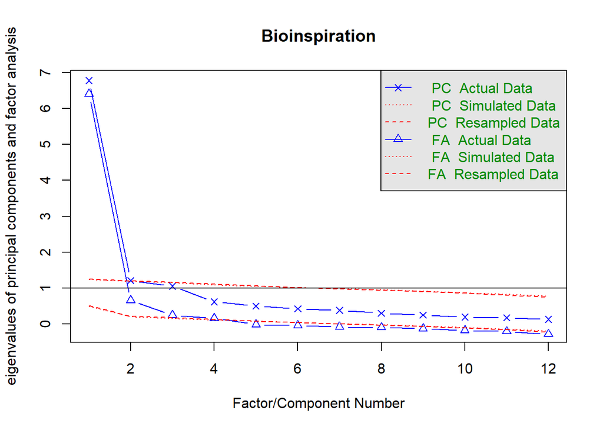

```
Parallel analysis suggests that the number of factors =  4  and the number of components =  2
Bioinspiration
Number of components:  2
```

```
EFA factor loadings (1 factor solution):

Loadings:
                     MR1
BioinspirationPN2r   -0.173
BioinspirationPN1     0.794
BioinspirationIPI4    0.866
BioinspirationVRtN4r  0.690
BioinspirationVRtN2   0.883
BioinspirationIPI1    0.845
BioinspirationVRtN1   0.814
BioinspirationIPI3    0.842
BioinspirationVRtN3   0.816
BioinspirationPN3     0.581
BioinspirationIPI2r   0.461
BioinspirationPN4     0.669

                 MR1
SS loadings    6.412
Proportion Var 0.534
CFA summary and fit statistics:
lavaan 0.6-19 ended normally after 51 iterations

  Estimator                                         ML
  Optimization method                           NLMINB
  Number of model parameters                        24

  Number of observations                           594

Model Test User Model:
                                              Standard      Scaled
  Test Statistic                               524.698     412.126
  Degrees of freedom                                54          54
  P-value (Chi-square)                           0.000       0.000
  Scaling correction factor                                  1.273
    Yuan-Bentler correction (Mplus variant)

Model Test Baseline Model:

  Test statistic                              4214.921    3159.829
```

[output cut: 65 more lines]

```
Variances:
                   Estimate  Std.Err  z-value  P(>|z|)   Std.lv  Std.all
   .BioinsprtnPN2r    1.119    0.053   20.947    0.000    1.119    0.964
   .BioinspirtnPN1    0.431    0.038   11.475    0.000    0.431    0.455
   .BioinsprtnIPI4    0.264    0.026   10.047    0.000    0.264    0.279
   .BinsprtnVRtN4r    0.691    0.063   10.986    0.000    0.691    0.569
   .BionsprtnVRtN2    0.344    0.032   10.661    0.000    0.344    0.286
   .BioinsprtnIPI1    0.290    0.028   10.275    0.000    0.290    0.293
   .BionsprtnVRtN1    0.453    0.039   11.714    0.000    0.453    0.421
   .BioinsprtnIPI3    0.291    0.026   11.342    0.000    0.291    0.327
   .BionsprtnVRtN3    0.404    0.032   12.571    0.000    0.404    0.419
   .BioinspirtnPN3    0.615    0.038   16.398    0.000    0.615    0.723
   .BionsprtnIPI2r    0.912    0.057   16.096    0.000    0.912    0.806
   .BioinspirtnPN4    0.702    0.044   16.009    0.000    0.702    0.618
    Bioinspiration    0.042    0.021    1.934    0.053    1.000    1.000
```

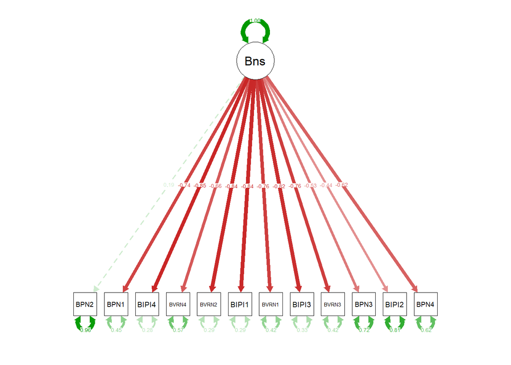

```
CFA first 6 Modification Indices:
                  lhs op                rhs     mi    epc sepc.lv sepc.all
49 BioinspirationIPI4 ~~ BioinspirationIPI1 83.606  0.132   0.132    0.476
44  BioinspirationPN1 ~~  BioinspirationPN3 71.077  0.188   0.188    0.366
46  BioinspirationPN1 ~~  BioinspirationPN4 67.447  0.198   0.198    0.360
72 BioinspirationIPI1 ~~ BioinspirationIPI3 52.170  0.106   0.106    0.363
51 BioinspirationIPI4 ~~ BioinspirationIPI3 43.220  0.093   0.093    0.334
74 BioinspirationIPI1 ~~  BioinspirationPN3 35.797 -0.115  -0.115   -0.273
   sepc.nox
49    0.476
44    0.366
46    0.360
72    0.363
51    0.334
74   -0.273
```

```r
tmp_dat <- na.omit(dat[,str_detect(string = colnames(dat), pattern = regEx)])


tmp <- CFAstats(dataset = tmp_dat, regularExp = regEx, labelLatent = str_remove(string = nameVariable, pattern = "mean_"),
                showPlots = TRUE,
                computeEFA = TRUE,
                computeCFA = TRUE,
                computeCFAMplus = FALSE)
```

### 4.4.3 Visual Resemblance to Nature

```r
regEx <- "^Bioinspiration-VRtN"
nameVariable <- "VRtN"


sum(str_detect(string = colnames(dat), pattern = regEx))
```

```
[1] 4
```

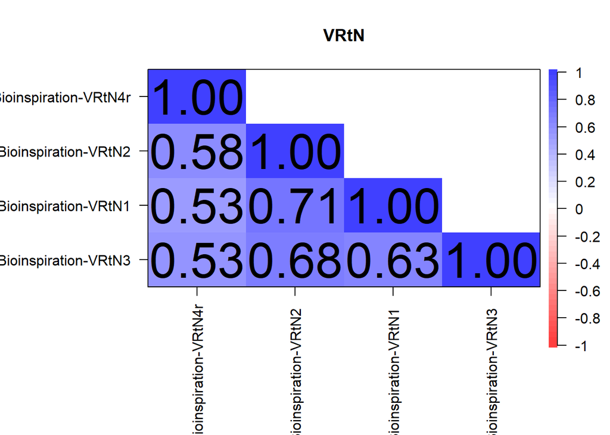

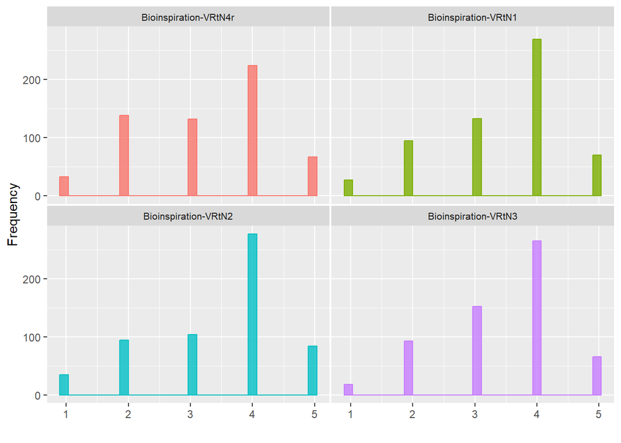

```
descriptive statistics:
                      Mean   SD Median CoeffofVariation Minimum Maximun
Bioinspiration-VRtN4r 3.26 1.10      3             0.34       1       5
Bioinspiration-VRtN2  3.47 1.10      4             0.32       1       5
Bioinspiration-VRtN1  3.44 1.04      4             0.30       1       5
Bioinspiration-VRtN3  3.45 0.98      4             0.28       1       5
                      Lower Quantile Upper Quantile Skewness Kurtosis(-3)
Bioinspiration-VRtN4r              1              5    -0.27        -0.85
Bioinspiration-VRtN2               1              5    -0.64        -0.40
Bioinspiration-VRtN1               1              5    -0.56        -0.36
Bioinspiration-VRtN3               1              5    -0.49        -0.34
                      KS-Test
Bioinspiration-VRtN4r       0
Bioinspiration-VRtN2        0
Bioinspiration-VRtN1        0
Bioinspiration-VRtN3        0


variables under investigation:  BioinspirationVRtN4r BioinspirationVRtN2 BioinspirationVRtN1 BioinspirationVRtN3

Cronbachs Alpha: 0.86
```

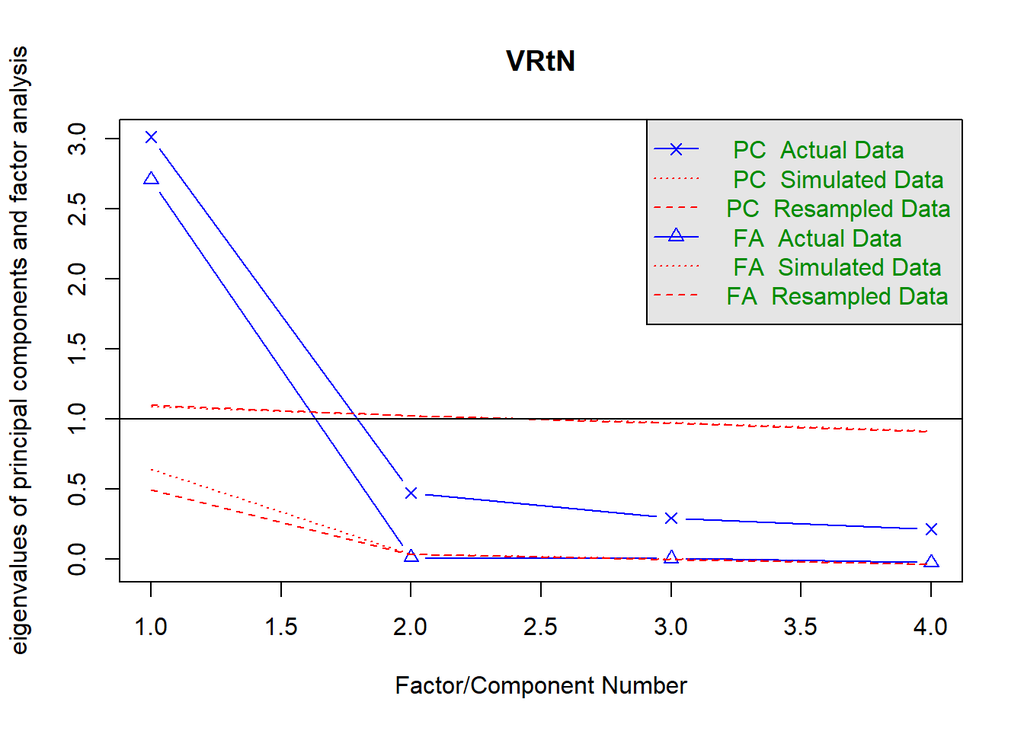

```
Parallel analysis suggests that the number of factors =  1  and the number of components =  1
VRtN
Number of components:  1



EFA factor loadings (1 factor solution):

Loadings:
                     MR1
BioinspirationVRtN4r 0.692
BioinspirationVRtN2  0.907
BioinspirationVRtN1  0.844
BioinspirationVRtN3  0.832

                 MR1
SS loadings    2.706
Proportion Var 0.677
CFA summary and fit statistics:
lavaan 0.6-19 ended normally after 20 iterations

  Estimator                                         ML
  Optimization method                           NLMINB
  Number of model parameters                         8

  Number of observations                           594

Model Test User Model:
                                              Standard      Scaled
  Test Statistic                                 1.238       0.928
  Degrees of freedom                                 2           2
  P-value (Chi-square)                           0.538       0.629
  Scaling correction factor                                  1.334
    Yuan-Bentler correction (Mplus variant)

Model Test Baseline Model:

  Test statistic                              1122.703     737.036
  Degrees of freedom                                 6           6
  P-value                                        0.000       0.000
```

[output cut: 47 more lines]

```
Latent Variables:
                   Estimate  Std.Err  z-value  P(>|z|)   Std.lv  Std.all
  VRtN =~
    BinsprtnVRtN4r    1.000                               0.733    0.665
    BionsprtnVRtN2    1.305    0.082   16.009    0.000    0.957    0.873
    BionsprtnVRtN1    1.145    0.074   15.440    0.000    0.840    0.810
    BionsprtnVRtN3    1.043    0.065   16.066    0.000    0.765    0.779

Variances:
                   Estimate  Std.Err  z-value  P(>|z|)   Std.lv  Std.all
   .BinsprtnVRtN4r    0.678    0.063   10.744    0.000    0.678    0.557
   .BionsprtnVRtN2    0.286    0.033    8.572    0.000    0.286    0.238
   .BionsprtnVRtN1    0.370    0.035   10.581    0.000    0.370    0.344
   .BionsprtnVRtN3    0.379    0.034   11.220    0.000    0.379    0.393
    VRtN              0.538    0.063    8.526    0.000    1.000    1.000
```

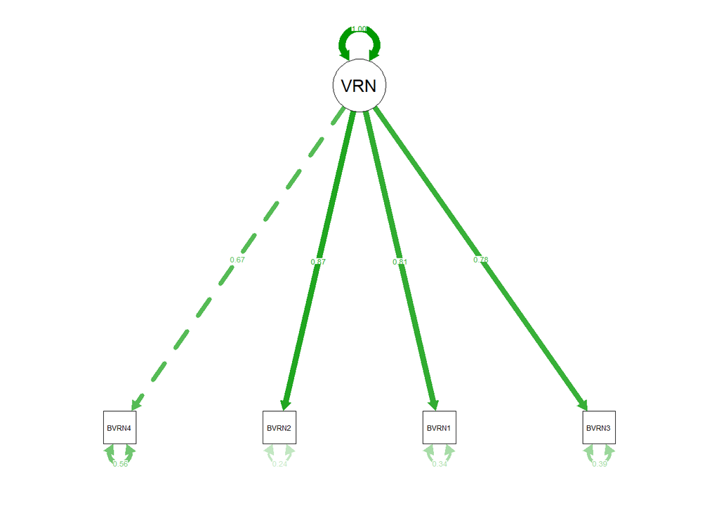

```
CFA first 6 Modification Indices:
                    lhs op                 rhs    mi    epc sepc.lv sepc.all
12 BioinspirationVRtN4r ~~ BioinspirationVRtN3 0.913  0.026   0.026    0.051
13  BioinspirationVRtN2 ~~ BioinspirationVRtN1 0.913  0.037   0.037    0.114
14  BioinspirationVRtN2 ~~ BioinspirationVRtN3 0.871 -0.032  -0.032   -0.096
11 BioinspirationVRtN4r ~~ BioinspirationVRtN1 0.871 -0.027  -0.027   -0.053
15  BioinspirationVRtN1 ~~ BioinspirationVRtN3 0.000  0.000   0.000    0.001
10 BioinspirationVRtN4r ~~ BioinspirationVRtN2 0.000  0.000   0.000    0.001
   sepc.nox
12    0.051
13    0.114
14   -0.096
11   -0.053
15    0.001
10    0.001
```

```r
tmp_dat <- na.omit(dat[,str_detect(string = colnames(dat), pattern = regEx)])


tmp <- CFAstats(dataset = tmp_dat, regularExp = regEx, labelLatent = str_remove(string = nameVariable, pattern = "mean_"),
                showPlots = TRUE,
                computeEFA = TRUE,
                computeCFA = TRUE,
                computeCFAMplus = FALSE)
```

### 4.4.4 Intentionality & Perceived Inspiration

```r
regEx <- "^Bioinspiration-IPI"
nameVariable <- "IPI"


sum(str_detect(string = colnames(dat), pattern = regEx))
```

```
[1] 4
```

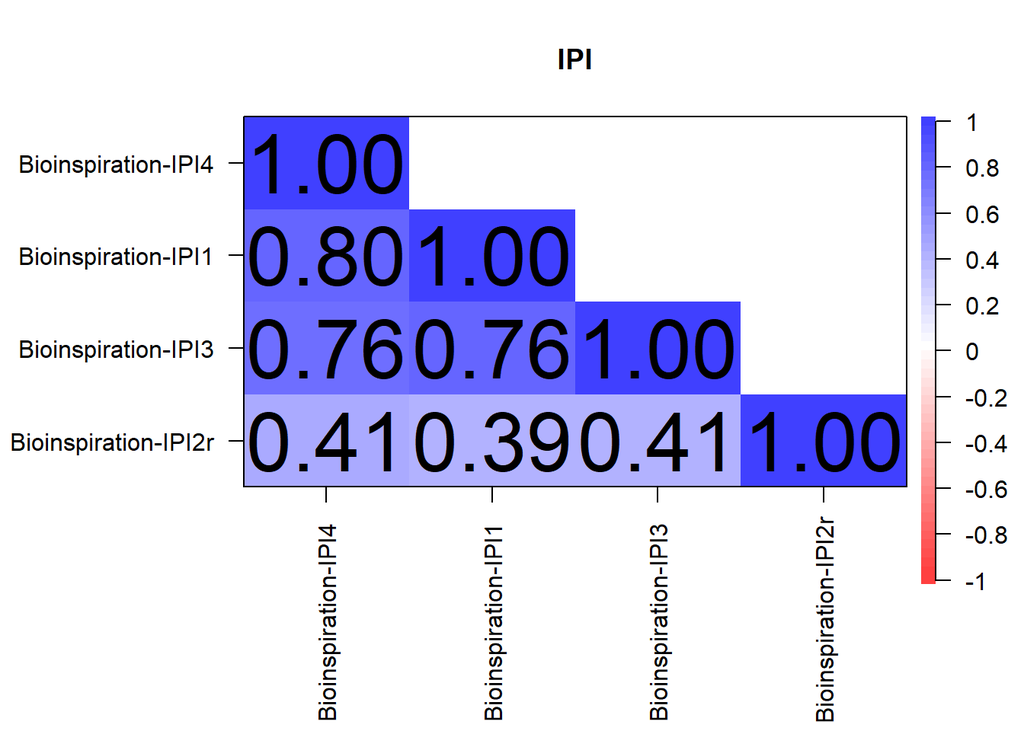

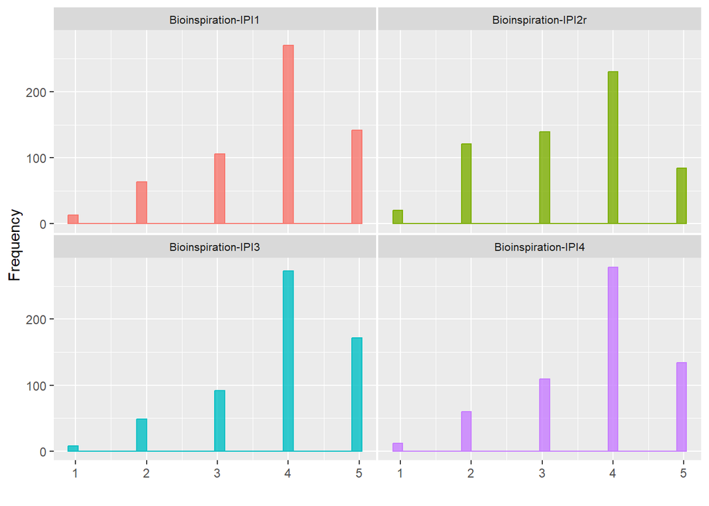

```
descriptive statistics:
                     Mean   SD Median CoeffofVariation Minimum Maximun
Bioinspiration-IPI4  3.78 0.97      4             0.26       1       5
Bioinspiration-IPI1  3.78 1.00      4             0.26       1       5
Bioinspiration-IPI3  3.93 0.94      4             0.24       1       5
Bioinspiration-IPI2r 3.40 1.06      4             0.31       1       5
                     Lower Quantile Upper Quantile Skewness Kurtosis(-3)
Bioinspiration-IPI4               1              5    -0.73         0.11
Bioinspiration-IPI1               1              5    -0.73         0.03
Bioinspiration-IPI3               1              5    -0.83         0.32
Bioinspiration-IPI2r              1              5    -0.31        -0.75
                     KS-Test
Bioinspiration-IPI4        0
Bioinspiration-IPI1        0
Bioinspiration-IPI3        0
Bioinspiration-IPI2r       0


variables under investigation:  BioinspirationIPI4 BioinspirationIPI1 BioinspirationIPI3 BioinspirationIPI2r

Cronbachs Alpha: 0.85
```

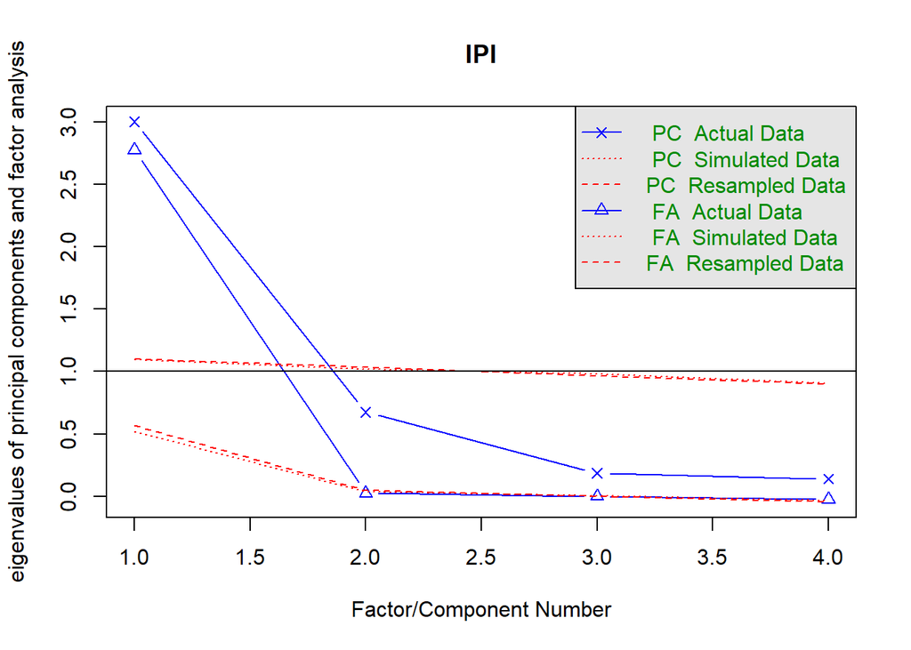

```
Parallel analysis suggests that the number of factors =  1  and the number of components =  1
IPI
Number of components:  1



EFA factor loadings (1 factor solution):

Loadings:
                    MR1
BioinspirationIPI4  0.925
BioinspirationIPI1  0.922
BioinspirationIPI3  0.900
BioinspirationIPI2r 0.509

                 MR1
SS loadings    2.776
Proportion Var 0.694
CFA summary and fit statistics:
lavaan 0.6-19 ended normally after 20 iterations

  Estimator                                         ML
  Optimization method                           NLMINB
  Number of model parameters                         8

  Number of observations                           594

Model Test User Model:
                                              Standard      Scaled
  Test Statistic                                 1.508       1.265
  Degrees of freedom                                 2           2
  P-value (Chi-square)                           0.470       0.531
  Scaling correction factor                                  1.193
    Yuan-Bentler correction (Mplus variant)

Model Test Baseline Model:

  Test statistic                              1351.155     792.040
  Degrees of freedom                                 6           6
  P-value                                        0.000       0.000
```

[output cut: 47 more lines]

```
Latent Variables:
                   Estimate  Std.Err  z-value  P(>|z|)   Std.lv  Std.all
  IPI =~
    BioinsprtnIPI4    1.000                               0.869    0.893
    BioinsprtnIPI1    1.022    0.034   29.782    0.000    0.889    0.892
    BioinsprtnIPI3    0.930    0.039   23.839    0.000    0.808    0.856
    BionsprtnIPI2r    0.559    0.050   11.162    0.000    0.486    0.457

Variances:
                   Estimate  Std.Err  z-value  P(>|z|)   Std.lv  Std.all
   .BioinsprtnIPI4    0.191    0.026    7.403    0.000    0.191    0.202
   .BioinsprtnIPI1    0.202    0.028    7.149    0.000    0.202    0.204
   .BioinsprtnIPI3    0.238    0.028    8.512    0.000    0.238    0.267
   .BionsprtnIPI2r    0.896    0.058   15.340    0.000    0.896    0.791
    IPI               0.755    0.060   12.500    0.000    1.000    1.000
```

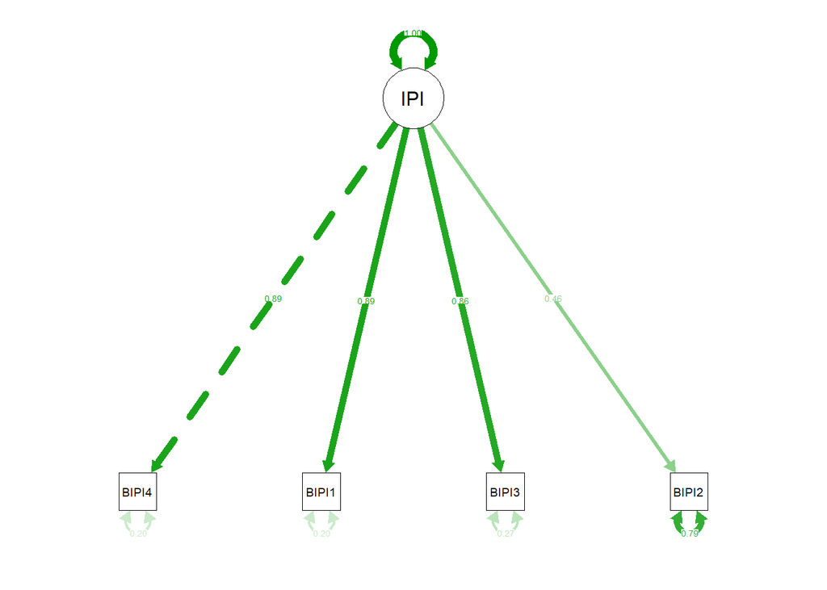

```
CFA first 6 Modification Indices:
                  lhs op                 rhs    mi    epc sepc.lv sepc.all
11 BioinspirationIPI4 ~~  BioinspirationIPI3 1.311 -0.043  -0.043   -0.200
14 BioinspirationIPI1 ~~ BioinspirationIPI2r 1.311 -0.026  -0.026   -0.062
10 BioinspirationIPI4 ~~  BioinspirationIPI1 0.821  0.040   0.040    0.205
15 BioinspirationIPI3 ~~ BioinspirationIPI2r 0.821  0.021   0.021    0.044
12 BioinspirationIPI4 ~~ BioinspirationIPI2r 0.097  0.007   0.007    0.017
13 BioinspirationIPI1 ~~  BioinspirationIPI3 0.097  0.012   0.012    0.054
   sepc.nox
11   -0.200
14   -0.062
10    0.205
15    0.044
12    0.017
13    0.054
```

```r
tmp_dat <- na.omit(dat[,str_detect(string = colnames(dat), pattern = regEx)])


tmp <- CFAstats(dataset = tmp_dat, regularExp = regEx, labelLatent = str_remove(string = nameVariable, pattern = "mean_"),
                showPlots = TRUE,
                computeEFA = TRUE,
                computeCFA = TRUE,
                computeCFAMplus = FALSE)
```

### 4.4.5 Perceived Naturalness

```r
regEx <- "^Bioinspiration-PN"
nameVariable <- "PN"


sum(str_detect(string = colnames(dat), pattern = regEx))
```

```
[1] 4
```

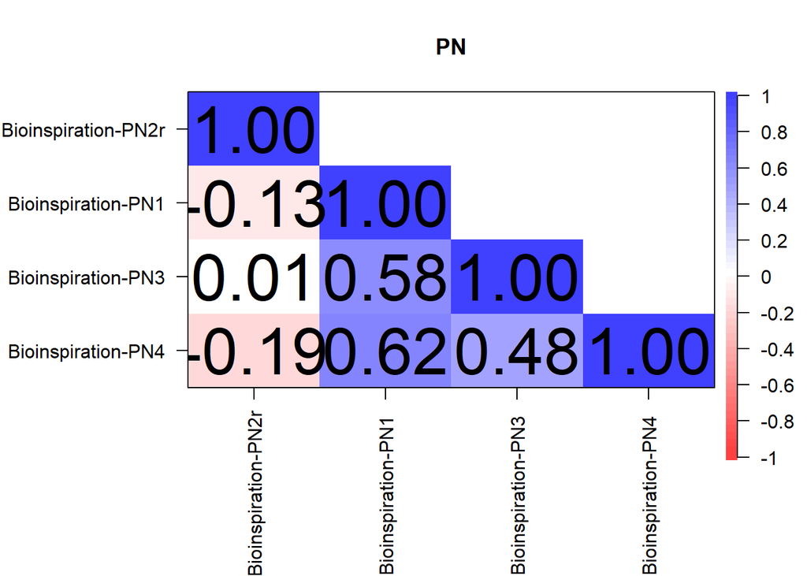

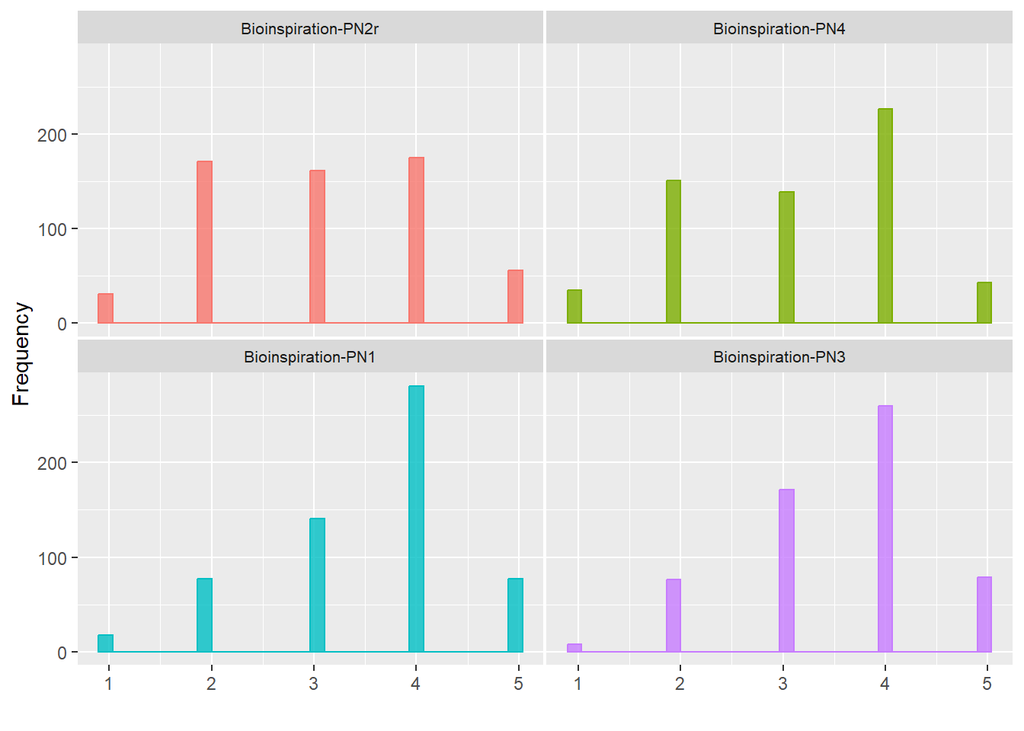

```
descriptive statistics:
                    Mean   SD Median CoeffofVariation Minimum Maximun
Bioinspiration-PN2r 3.09 1.08      3             0.35       1       5
Bioinspiration-PN1  3.54 0.97      4             0.28       1       5
Bioinspiration-PN3  3.55 0.92      4             0.26       1       5
Bioinspiration-PN4  3.15 1.07      3             0.34       1       5
                    Lower Quantile Upper Quantile Skewness Kurtosis(-3) KS-Test
Bioinspiration-PN2r              1              5     0.02        -0.88       0
Bioinspiration-PN1               1              5    -0.61        -0.08       0
Bioinspiration-PN3               1              5    -0.38        -0.32       0
Bioinspiration-PN4               1              5    -0.24        -0.87       0


variables under investigation:  BioinspirationPN2r BioinspirationPN1 BioinspirationPN3 BioinspirationPN4
```

```
Some items ( Bioinspiration-PN2r ) were negatively correlated with the first principal component and
probably should be reversed.
To do this, run the function again with the 'check.keys=TRUE' optionCronbachs Alpha: 0.54
```

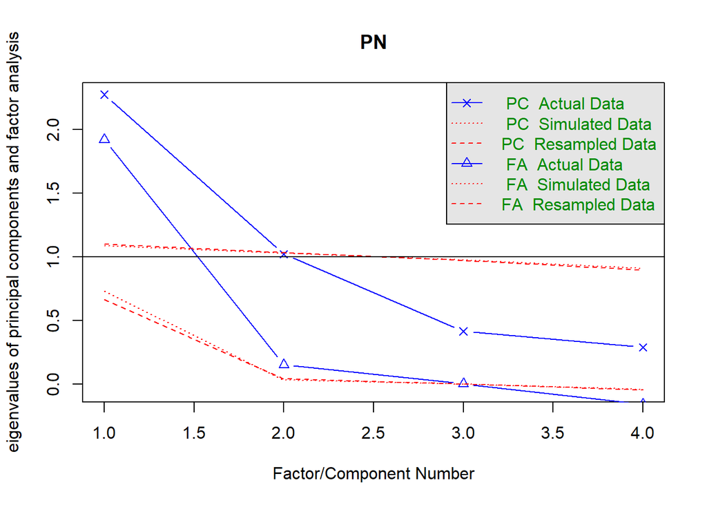

```
Parallel analysis suggests that the number of factors =  2  and the number of components =  1
PN
Number of components:  1

KMO criteria is to low (< .6) for:
 BioinspirationPN2r
 mean KMO: 0.69


EFA factor loadings (1 factor solution):

Loadings:
                   MR1
BioinspirationPN2r -0.132
BioinspirationPN1   0.904
BioinspirationPN3   0.696
BioinspirationPN4   0.775

                 MR1
SS loadings    1.919
Proportion Var 0.480
CFA summary and fit statistics:
lavaan 0.6-19 ended normally after 41 iterations

  Estimator                                         ML
  Optimization method                           NLMINB
  Number of model parameters                         8

  Number of observations                           594

Model Test User Model:
                                              Standard      Scaled
  Test Statistic                                21.304      16.653
  Degrees of freedom                                 2           2
  P-value (Chi-square)                           0.000       0.000
  Scaling correction factor                                  1.279
    Yuan-Bentler correction (Mplus variant)

Model Test Baseline Model:

```

[output cut: 50 more lines]

```
Latent Variables:
                   Estimate  Std.Err  z-value  P(>|z|)   Std.lv  Std.all
  PN =~
    BioinsprtnPN2r    1.000                               0.161    0.149
    BioinspirtnPN1   -5.224    1.815   -2.879    0.004   -0.841   -0.863
    BioinspirtnPN3   -3.791    1.377   -2.753    0.006   -0.610   -0.662
    BioinspirtnPN4   -4.813    1.653   -2.912    0.004   -0.775   -0.727

Variances:
                   Estimate  Std.Err  z-value  P(>|z|)   Std.lv  Std.all
   .BioinsprtnPN2r    1.134    0.053   21.438    0.000    1.134    0.978
   .BioinspirtnPN1    0.242    0.047    5.090    0.000    0.242    0.255
   .BioinspirtnPN3    0.478    0.038   12.534    0.000    0.478    0.562
   .BioinspirtnPN4    0.536    0.051   10.488    0.000    0.536    0.472
    PN                0.026    0.018    1.418    0.156    1.000    1.000
```

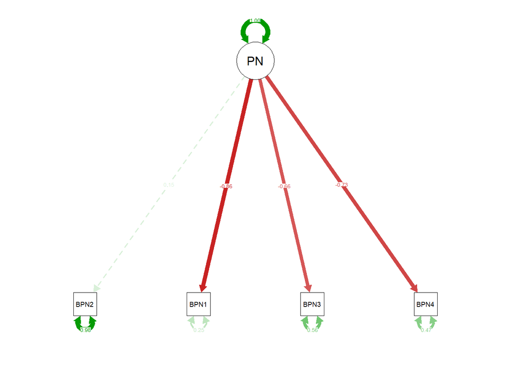

```
CFA first 6 Modification Indices:
                  lhs op               rhs     mi    epc sepc.lv sepc.all
11 BioinspirationPN2r ~~ BioinspirationPN3 15.241  0.130   0.130    0.176
14  BioinspirationPN1 ~~ BioinspirationPN4 15.241 -0.860  -0.860   -2.390
12 BioinspirationPN2r ~~ BioinspirationPN4 10.826 -0.121  -0.121   -0.156
13  BioinspirationPN1 ~~ BioinspirationPN3 10.826  0.500   0.500    1.471
15  BioinspirationPN3 ~~ BioinspirationPN4  0.012  0.014   0.014    0.027
10 BioinspirationPN2r ~~ BioinspirationPN1  0.012 -0.004  -0.004   -0.007
   sepc.nox
11    0.176
14   -2.390
12   -0.156
13    1.471
15    0.027
10   -0.007
```

```r
tmp_dat <- na.omit(dat[,str_detect(string = colnames(dat), pattern = regEx)])


tmp <- CFAstats(dataset = tmp_dat, regularExp = regEx, labelLatent = str_remove(string = nameVariable, pattern = "mean_"),
                showPlots = TRUE,
                computeEFA = TRUE,
                computeCFA = TRUE,
                computeCFAMplus = FALSE)
```

## 4.5 Delete Items

```r
dat$`Bioinspiration-PN2r` <- NULL
```

## 4.6 Item Response Theory (polytomous) for “Bioinspiration Items”

Factor Loadings (F1) indicate how strongly each item is associated with the latent trait, rule of thumb:

- 0.70 = strong
- 0.40–0.69 = moderate
- < 0.40 = weak

Communality (h²) is the proportion of variance in each item explained by the factor, rule of thumb: + h² > 0.40 → item is well represented + h² < 0.30 → potentially problematic item

```r
# Choose dataset and regular expression
regEx <- "^Bioinspiration"

# Filter variables matching the pattern
irt_items <- dat[, str_detect(colnames(dat), pattern = regEx)]

# Drop rows with missing data (mirt requires complete cases)
irt_items <- na.omit(irt_items)

# Ensure all items are treated as ordered factors
irt_items[] <- lapply(irt_items, function(x) as.numeric(as.character(x)))
# Fit Graded Response Model (1-factor)
mod_grm <- mirt(data = irt_items, model = 1, itemtype = "graded", verbose = FALSE)

# Summarize model
summary(mod_grm)
```

```
                         F1    h2
Bioinspiration-PN1    0.796 0.634
Bioinspiration-IPI4   0.908 0.825
Bioinspiration-VRtN4r 0.742 0.551
Bioinspiration-VRtN2  0.894 0.800
Bioinspiration-IPI1   0.894 0.800
Bioinspiration-VRtN1  0.814 0.663
Bioinspiration-IPI3   0.884 0.781
Bioinspiration-VRtN3  0.822 0.676
Bioinspiration-PN3    0.586 0.343
Bioinspiration-IPI2r  0.515 0.266
Bioinspiration-PN4    0.679 0.461

SS loadings:  6.799
Proportion Var:  0.618

Factor correlations:

   F1
F1  1
```

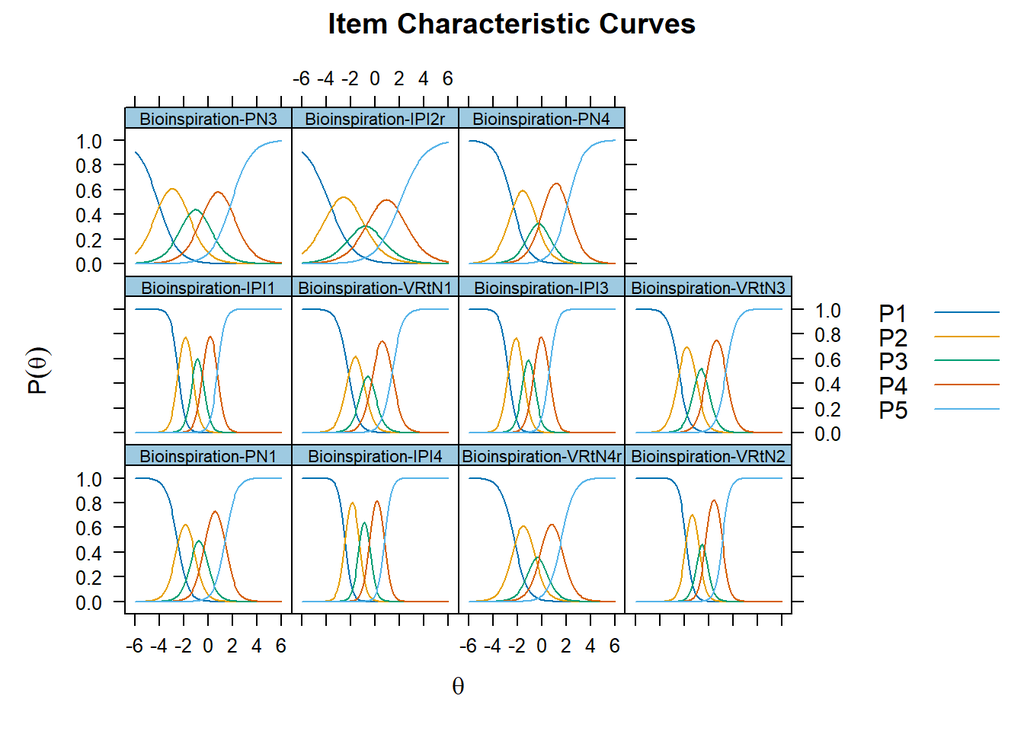

```r
# Plot Item Characteristic Curves (ICCs) for all items
plot(mod_grm, type = "trace", facet_items = TRUE, main = "Item Characteristic Curves")
```

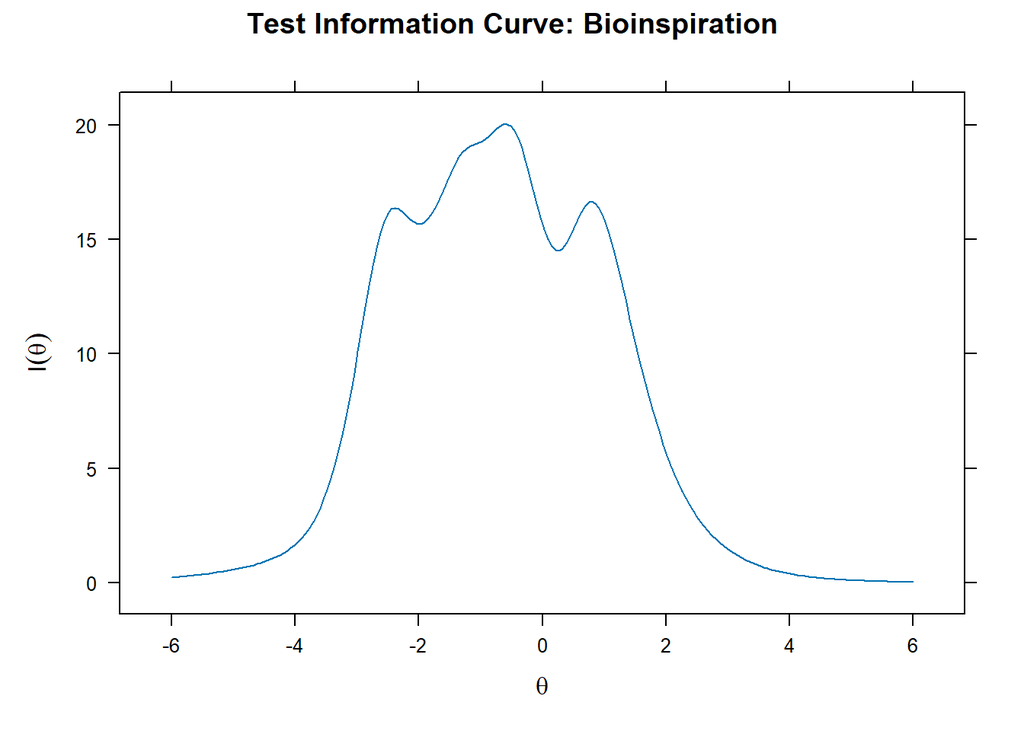

```r
# Plot Test Information Curve
plot(mod_grm, type = "info", main = "Test Information Curve: Bioinspiration")
```

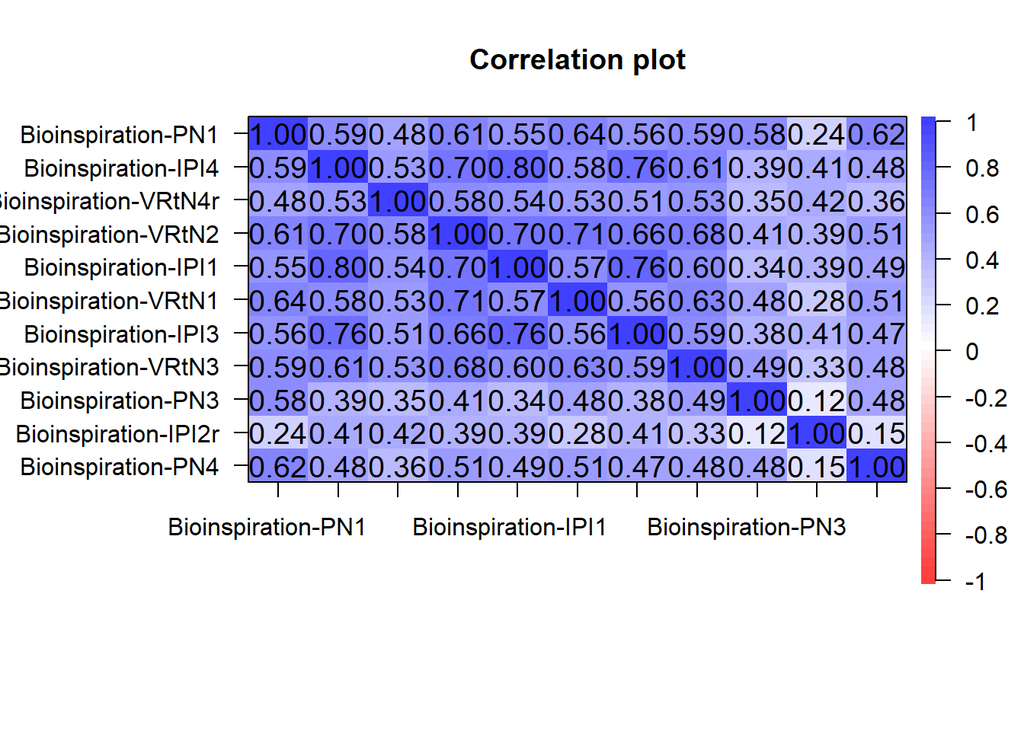

```r
### compare results to:
cor.plot(r = cor(irt_items))
```

Compare 1-Factor vs. 2-Factor Models:

```r
mod_1f <- mirt(data = irt_items, model = 1, itemtype = "graded", verbose = FALSE)
mod_2f <- mirt(data = irt_items, model = 2, itemtype = "graded", verbose = FALSE)
mod_3f <- mirt(data = irt_items, model = 3, itemtype = "graded", verbose = FALSE)
anova(mod_1f, mod_2f, mod_3f)
```

```
            AIC    SABIC       HQ      BIC    logLik      X2 df p
mod_1f 14244.40 14311.07 14338.37 14485.68 -7067.199
mod_2f 13930.42 14009.21 14041.47 14215.56 -6900.207 333.984 10 0
mod_3f 13875.44 13965.14 14001.87 14200.07 -6863.719  72.976  9 0
```

```r
summary(mod_2f)
```

```
Rotation:  oblimin

Rotated factor loadings:

                           F1      F2    h2
Bioinspiration-PN1     0.8206  0.0939 0.789
Bioinspiration-IPI4    0.0576  0.8953 0.876
Bioinspiration-VRtN4r  0.2874  0.5092 0.545
Bioinspiration-VRtN2   0.3887  0.5721 0.786
Bioinspiration-IPI1   -0.0262  0.9556 0.879
Bioinspiration-VRtN1   0.6285  0.2785 0.715
Bioinspiration-IPI3    0.0524  0.8710 0.825
Bioinspiration-VRtN3   0.5420  0.3615 0.696
Bioinspiration-PN3     0.8705 -0.1694 0.582
Bioinspiration-IPI2r  -0.1880  0.7049 0.349
Bioinspiration-PN4     0.7028  0.0742 0.572

Rotated SS loadings:  2.89 3.808

Factor correlations:

      F1 F2
F1 1.000
F2 0.693  1
```

```r
summary(mod_3f)
```

```
Rotation:  oblimin

Rotated factor loadings:

                            F1      F2       F3    h2
Bioinspiration-PN1     0.51245  0.1925  0.36832 0.801
Bioinspiration-IPI4    0.03886  0.8876  0.04312 0.877
Bioinspiration-VRtN4r -0.09635  0.1354  0.68409 0.575
Bioinspiration-VRtN2  -0.05536  0.1544  0.80541 0.832
Bioinspiration-IPI1   -0.00474  0.9498 -0.00925 0.885
Bioinspiration-VRtN1   0.11126 -0.0927  0.88065 0.754
Bioinspiration-IPI3    0.03194  0.8625  0.04339 0.827
Bioinspiration-VRtN3   0.08199  0.0477  0.75909 0.710
Bioinspiration-PN3     0.51609 -0.0510  0.38173 0.565
Bioinspiration-IPI2r  -0.33803  0.3317  0.38126 0.383
Bioinspiration-PN4     0.58423  0.3574  0.02875 0.627

Rotated SS loadings:  1.019 2.765 2.9

Factor correlations:

      F1    F2 F3
F1 1.000
F2 0.296 1.000
F3 0.503 0.828  1
```